# Korean dyads - analysis of lexical data

Bodo

29/10/2020

## Prelims

Load packages:

```r
library(tidyverse)
library(brms)
library(chron)
library(patchwork)
library(effsize)
```

R and package versions for reporting and reproducibility:

```r
R.Version()
```

```
## $platform
## [1] "x86_64-apple-darwin17.0"
##
## $arch
## [1] "x86_64"
##
## $os
## [1] "darwin17.0"
##
## $system
## [1] "x86_64, darwin17.0"
##
## $status
## [1] ""
##
## $major
## [1] "4"
##
## $minor
## [1] "0.2"
##
## $year
## [1] "2020"
##
## $month
## [1] "06"
##
## $day
## [1] "22"
##
## $`svn rev`
## [1] "78730"
##
## $language
## [1] "R"
##
## $version.string
## [1] "R version 4.0.2 (2020-06-22)"
##
## $nickname
## [1] "Taking Off Again"
```

```r
packageVersion('tidyverse')
```

```
## [1] '1.3.0'
```

```r
packageVersion('brms')
```

```
## [1] '2.14.4'
```

```r
packageVersion('chron')
```

```
## [1] '2.3.56'
```

```r
packageVersion('patchwork')
```

```
## [1] '1.1.1'
```

```r
packageVersion('effsize')
```

```
## [1] '0.8.1'
```

For data loading, first, get the right working directory:

```r
# Save current directory:

current_dir <- getwd()

# Get all file names:

all_files <- list.files('../data/')

# Create variable names from file names:

var_names <- str_replace(all_files, '\\.csv', '')
```

Loop through all the files and load them in:

```r
for (i in seq_along(all_files)) {
  assign(var_names[i], read_csv(str_c('../data/', all_files[i])))
}
```

Make them all into long format:

```r
for (i in seq_along(var_names)) {
  x <- get(var_names[i])
  x <- pivot_longer(x,
                    cols = Movie:Map2,
                    names_to = 'Task',
                    values_to = 'Count')
  assign(var_names[i], x)
}
```

Put them all into one big data file, making the duration one the basis. Let’s process the durations first:

```r
dur <- dur %>% rename(Dur = Count) %>%
  mutate(Seconds = times(Dur) * 60 * 24,
         Seconds = as.vector(Seconds),
         LogDur = log(Seconds))
```

Append all to this durations tibble:

```r
# vector of var_names without duration:

var_nodur <- var_names[var_names != 'dur']

# loop through that and append to the dur frame:

for (i in seq_along(var_nodur)) {
  x <- get(var_nodur[i])
  x <- select(x, Count) # select 'Count' column
  colnames(x) <- var_nodur[i]
  dur <- bind_cols(dur, x)
}
```

Rename the main tibble:

```r
lex <- dur
```

Now that it’s all together, let’s get rid of all other data frames:

```r
rm(list = ls()[!ls() %in% c('lex', 'var_nodur', 'current_dir')])
```

## Descriptive statistics

Compute the overall counts for each of these variables:

```r
lex_tab <- lex %>% group_by(Condition) %>%
  summarize_at(.vars = var_nodur, .funs = sum) %>%
  pivot_longer(cols = backchannels:total_utterances) %>%
  pivot_wider(names_from = Condition)
```

Append durations:

```r
durs <- lex %>% group_by(Condition) %>%
  summarize(TotalSeconds = sum(Seconds)) %>%
  pull(TotalSeconds)
```

First is friend, second is professor. Use this to calculate percentages and rates:

```r
lex_tab <- lex_tab %>%
  mutate(prof_per = professor / (professor + friend),
         prof_per = round(prof_per, 2),
         prof_per = str_c(prof_per * 100, '%')) %>%
  mutate(friend_rate = friend / durs[1],
         professor_rate = professor / durs[2],
         ProfFriendRateRatio = professor_rate / friend_rate,
         FriendProfRateRatio = friend_rate / professor_rate) %>%
  mutate(ProfFriendRateRatio = round(ProfFriendRateRatio, 2),
         FriendProfRateRatio = round(FriendProfRateRatio, 2))

# Check:

lex_tab
```

```
## # A tibble: 16 x 8
##    name  friend professor prof_per friend_rate professor_rate ProfFriendRateR…
##    <chr>  <dbl>     <dbl> <chr>          <dbl>          <dbl>            <dbl>
##  1 back…   1056       848 45%        0.0695          0.0733               1.05
##  2 case…    744       293 28%        0.0490          0.0253               0.52
##  3 cont…  11223      9051 45%        0.739           0.783                1.06
##  4 dati…      1        17 94%        0.0000658       0.00147             22.3
##  5 dati…     72        39 35%        0.00474         0.00337              0.71
##  6 fill…   1410       487 26%        0.0928          0.0421               0.45
##  7 hago…     31        13 30%        0.00204         0.00112              0.55
##  8 hiss…     61        89 59%        0.00402         0.00770              1.92
##  9 hono…     76      1720 96%        0.00500         0.149               29.7
## 10 hono…     88      1071 92%        0.00579         0.0926              16.0
## 11 ideo…    303       187 38%        0.0199          0.0162               0.81
## 12 kwa       11         8 42%        0.000724        0.000692             0.96
## 13 morp…  28992     22550 44%        1.91            1.95                 1.02
## 14 pron…   1021       493 33%        0.0672          0.0426               0.63
## 15 sino…   1615      1691 51%        0.106           0.146                1.38
## 16 tota…   5496      3946 42%        0.362           0.341                0.94
## # … with 1 more variable: FriendProfRateRatio <dbl>
```

Write this to table:

```r
write_csv(lex_tab, '../summary_tables/count_rate_summary.csv')
```

Look at how many participants had more/less/same. First, we create a rate data frame with the rates:

```r
rates <- lex

for (i in seq_along(var_nodur)) {
  this_var <- var_nodur[i]
  rates[, this_var] <- rates[, this_var] / rates$Seconds
}
```

Get the averages per subject for each condition:

```r
rates_ppt <- rates %>%
  group_by(ID, Sex, Condition) %>%
  summarize_at(.vars = var_nodur,
               .funs = mean)
```

Check for how many they are same/smaller/larger:

```r
# Initialize empty object:

indiv_diff <- c()

# Loop through variables and append that info to the data frame:

for (i in seq_along(var_nodur)) {
  friend <- unlist(rates_ppt[rep(c(TRUE, FALSE), 14), var_nodur[i]])
  prof <- unlist(rates_ppt[rep(c(FALSE, TRUE), 14), var_nodur[i]])

  friend_more <- as.vector(friend > prof)
  prof_more <- as.vector(prof > friend)
  same <- as.vector(prof == friend)

  df <- data.frame(variable = var_nodur[i],
                   friend_more = sum(friend_more),
                   prof_more = sum(prof_more),
                   same = sum(same)) # unlikely to happen, but just in case

  indiv_diff <- rbind(indiv_diff, df)
}
```

Write this to table:

```r
write_csv(indiv_diff, '../summary_tables/rate_comparison.csv')
```

## Data visualization

We want to plot the rates on the y-axis, separately for friend and professor (x-axis categories). Each data point will be one subject:

```r
lex_avg <- lex %>%
  mutate(backchannels = backchannels / Seconds,
            case_ellipsis = case_ellipsis / Seconds,
            dative_eykey = dative_eykey / Seconds,
            dative_hanthey = dative_hanthey / Seconds,
            fillers = fillers / Seconds,
            hago_lang = hago_lang / Seconds,
            hisses = hisses / Seconds,
            honorific_lexemes = honorific_lexemes / Seconds,
            honorific_suffixes = honorific_suffixes / Seconds,
            ideophones = ideophones / Seconds,
            kwa = kwa / Seconds,
            pronouns = pronouns / Seconds,
            sinokorean = sinokorean / Seconds) %>%
  group_by(ID, Sex,Condition) %>%
  summarize(backchannels = mean(backchannels),
            case_ellipsis = mean(case_ellipsis),
            dative_eykey = mean(dative_eykey),
            dative_hanthey = mean(dative_hanthey),
            fillers = mean(fillers),
            hago_lang = mean(hago_lang),
            hisses = mean(hisses),
            honorific_lexemes = mean(honorific_lexemes),
            honorific_suffixes = mean(honorific_suffixes),
            ideophones = mean(ideophones),
            kwa = mean(kwa),
            pronouns = mean(pronouns),
            sinokorean = mean(sinokorean))
```

Actually, with this data it makes sense to calculate effect size. For this, get the relevant variables names:

```r
var_names <- lex_avg %>% ungroup() %>%
  select(backchannels:sinokorean) %>% colnames()
```

Loop through these variables, compute paired Cohen’s d (ignoring the error message since order of ID variables is appropriately paired), and save this as a separate file:

```r
d_tab <- c()
for (i in seq_along(var_names)) {
  this_f <- as.formula(str_c(var_names[i], '~ Condition | Subject(ID)'))
  this_d <- cohen.d(this_f, paired = TRUE, data = lex_avg)
  this_d <- this_d$estimate
  d_tab <- rbind(d_tab,
                 data.frame(var = var_names[i], d = this_d))
}
```

```r
d_tab <- mutate(d_tab,
                d = round(d, 2))

# Save:

write_csv(d_tab, '../summary_tables/cohen_d.csv')
```

Re-label the condition variable for more transparency:

```r
lex_avg <- lex_avg %>%
  mutate(Condition = ifelse(Condition == 'friend',
                            'with\nfriend',
                            'with\nprofessor'))
```

Create a plot for ideophones:

```r
ideo_p <- lex_avg %>% ggplot(aes(x = Condition, y = ideophones,
                       group = ID,
                       fill = Condition)) +
  geom_line(col = 'grey') +
  geom_point(size = 3, shape = 21,
             alpha = 0.85) +
  scale_fill_manual(values = c("#E69F00", "#0072B2")) +
  xlab('') +
  ylab('Rate of ideophones') +
  theme_minimal() +
  theme(legend.position = 'none') +
  theme(axis.title.y = element_text(margin = margin(t = 0, r = 16,
                                                    b = 0, l = 0),
                                    size = 16, face = 'bold'),
        axis.text.x = element_text(face = 'bold', size = 12))

# Save:

ggsave(plot = ideo_p, filename = '../figures/ideophones.pdf',
       width = 3, height = 4)
```

Create a plot for case ellipsis:

```r
case_p <- lex_avg %>% ggplot(aes(x = Condition, y = case_ellipsis,
                       group = ID,
                       fill = Condition)) +
  geom_line(col = 'grey') +
  geom_point(size = 3, shape = 21,
             alpha = 0.85) +
  scale_fill_manual(values = c("#E69F00", "#0072B2")) +
  xlab('') +
  ylab('Rate of case ellipsis') +
  theme_minimal() +
  theme(legend.position = 'none') +
  theme(axis.title.y = element_text(margin = margin(t = 0, r = 16,
                                                    b = 0, l = 0),
                                    size = 16, face = 'bold'),
        axis.text.x = element_text(face = 'bold', size = 12))

# Save:

ggsave(plot = case_p, filename = '../figures/case_ellipsis.pdf',
       width = 3, height = 4)
```

Create a plot for pronouns:

```r
pronouns_p <- lex_avg %>% ggplot(aes(x = Condition, y = pronouns,
                       group = ID,
                       fill = Condition)) +
  geom_line(col = 'grey') +
  geom_point(size = 3, shape = 21,
             alpha = 0.85) +
  scale_fill_manual(values = c("#E69F00", "#0072B2")) +
  xlab('') +
  ylab('Rate of pronouns') +
  theme_minimal() +
  theme(legend.position = 'none') +
  theme(axis.title.y = element_text(margin = margin(t = 0, r = 16,
                                                    b = 0, l = 0),
                                    size = 16, face = 'bold'),
        axis.text.x = element_text(face = 'bold', size = 12))

# Save:

ggsave(plot = pronouns_p, filename = '../figures/pronouns.pdf',
       width = 3, height = 4)
```

Create a plot for rate of back channels, and next to it one with fillers:

```r
backchannel_p <- lex_avg %>% ggplot(aes(x = Condition, y = backchannels,
                       group = ID,
                       fill = Condition)) +
  geom_line(col = 'grey') +
  geom_point(size = 3, shape = 21,
             alpha = 0.85) +
  scale_fill_manual(values = c("#E69F00", "#0072B2")) +
  xlab('') +
  scale_y_continuous(breaks = seq(0.02, 0.12, 0.02),
                     limits = c(0.01, 0.13)) +
  ylab('Rate') +
  ggtitle('(a) Backchannels') +
  theme_minimal() +
  theme(legend.position = 'none') +
  theme(axis.title.y = element_text(margin = margin(t = 0, r = 16,
                                                    b = 0, l = 0),
                                    size = 16, face = 'bold'),
        axis.text.x = element_text(face = 'bold', size = 12),
        plot.title = element_text(face = 'bold'))

fillers_p <- lex_avg %>% ggplot(aes(x = Condition, y = fillers,
                       group = ID,
                       fill = Condition)) +
  geom_line(col = 'grey') +
  geom_point(size = 3, shape = 21,
             alpha = 0.85) +
  scale_fill_manual(values = c("#E69F00", "#0072B2")) +
  xlab('') +
  ylab('') +
  scale_y_continuous(breaks = seq(0.02, 0.12, 0.02),
                     limits = c(0.01, 0.13)) +
  theme_minimal() +
  theme(legend.position = 'none') +
  ggtitle('(b) um/uh-type sounds') +
  theme(axis.title.y = element_text(margin = margin(t = 0, r = 16,
                                                    b = 0, l = 0),
                                    size = 16, face = 'bold'),
        axis.text.x = element_text(face = 'bold', size = 12),
        plot.title = element_text(face = 'bold'))
both_p <- backchannel_p + fillers_p

ggsave(plot = both_p, filename = '../figures/backchannels_fillers.pdf',
       width = 6, height = 4)
```

Create a plot for honorifics:

```r
hon_suffix_p <- lex_avg %>% ggplot(aes(x = Condition,
                                       y = honorific_suffixes,
                                       group = ID,
                                       fill = Condition)) +
  geom_line(col = 'grey') +
  geom_point(size = 3, shape = 21,
             alpha = 0.85) +
  scale_fill_manual(values = c("#E69F00", "#0072B2")) +
  xlab('') +
  scale_y_continuous(breaks = seq(0, 0.25, 0.05),
                     limits = c(0, 0.25)) +
  ylab('Rate') +
  ggtitle('(a) Addressee honorifics') +
  theme_minimal() +
  theme(legend.position = 'none') +
  theme(axis.title.y = element_text(margin = margin(t = 0, r = 16,
                                                    b = 0, l = 0),
                                    size = 16, face = 'bold'),
        axis.text.x = element_text(face = 'bold', size = 12),
        plot.title = element_text(face = 'bold'))

hon_lex_p <- lex_avg %>% ggplot(aes(x = Condition,
                                    y = honorific_lexemes,
                                    group = ID,
                                    fill = Condition)) +
  geom_line(col = 'grey') +
  geom_point(size = 3, shape = 21,
             alpha = 0.85) +
  scale_fill_manual(values = c("#E69F00", "#0072B2")) +
  xlab('') +
  ylab('') +
  scale_y_continuous(breaks = seq(0, 0.25, 0.05),
                     limits = c(0, 0.25)) +
  theme_minimal() +
  theme(legend.position = 'none') +
  ggtitle('(b) Referent honorifics') +
  theme(axis.title.y = element_text(margin = margin(t = 0, r = 16,
                                                    b = 0, l = 0),
                                    size = 16, face = 'bold'),
        axis.text.x = element_text(face = 'bold', size = 12),
        plot.title = element_text(face = 'bold'))
both_p <- hon_suffix_p + hon_lex_p

ggsave(plot = both_p, filename = '../figures/honorifics.pdf',
       width = 6, height = 4)
```

## Check gender

It is possible that there are gender differences, particularly for some of the variables that show mixed results. Here, it would be useful to look at individual differences with respect to male/female, at least exploratively since we don’t have clear predictions for gender for most of these variables.

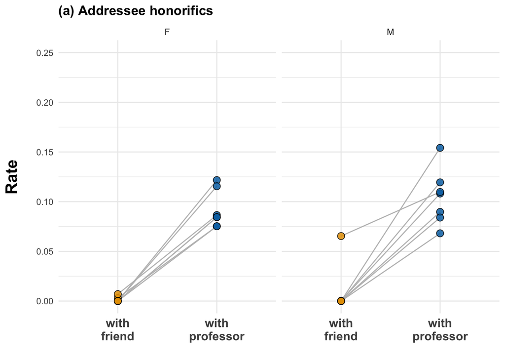

```r
hon_suffix_p + facet_wrap(~Sex)
```

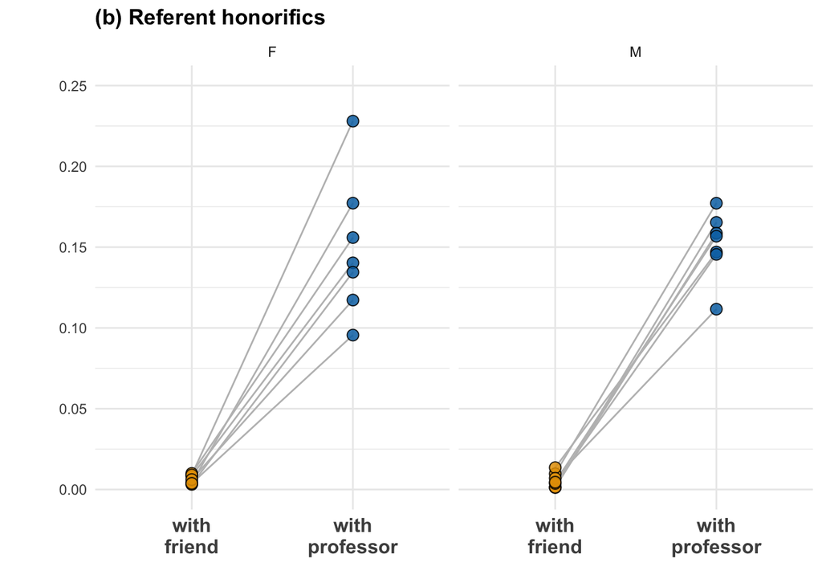

```r
hon_lex_p + facet_wrap(~Sex)
```

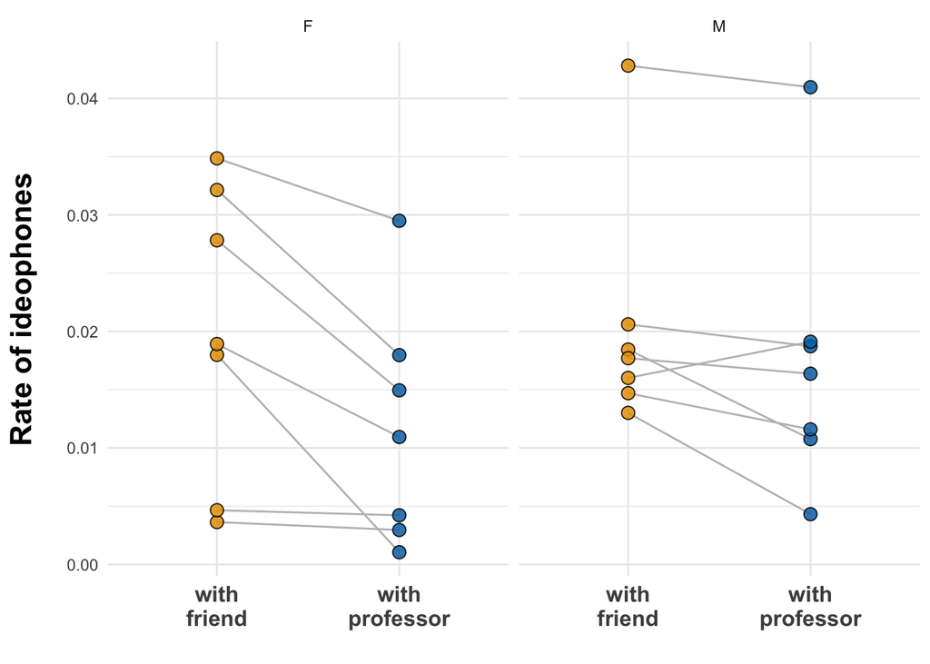

```r
ideo_p + facet_wrap(~Sex)
```

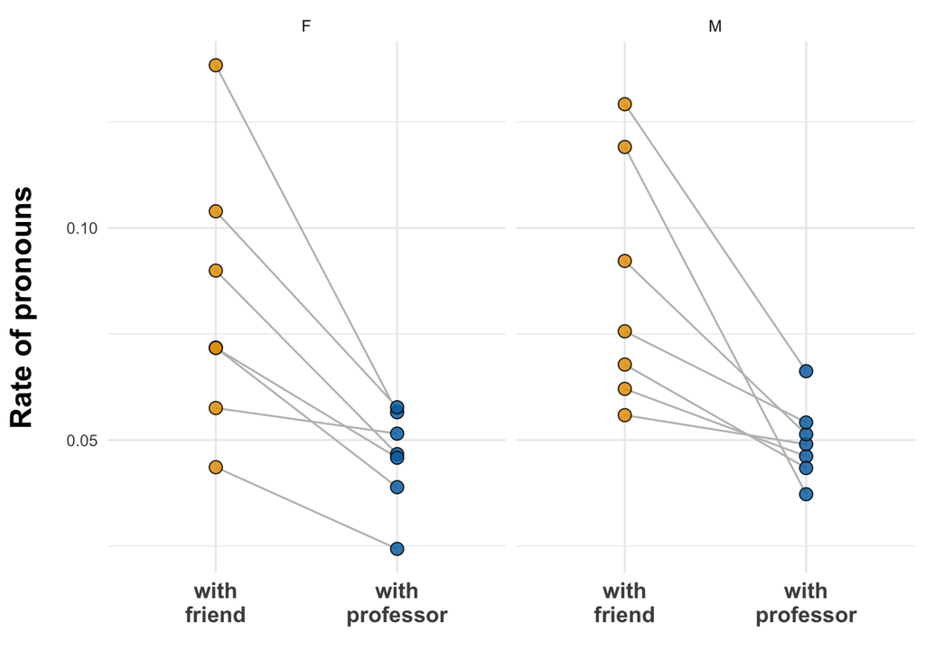

```r
pronouns_p + facet_wrap(~Sex)
```

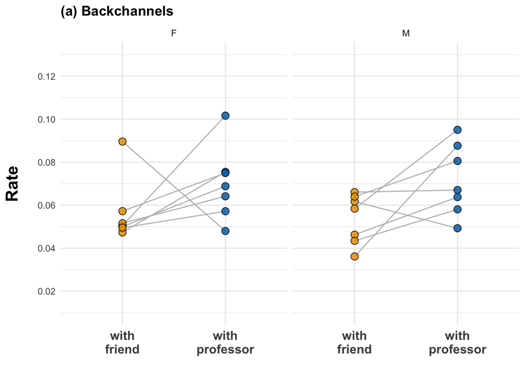

```r
backchannel_p + facet_wrap(~Sex)
```

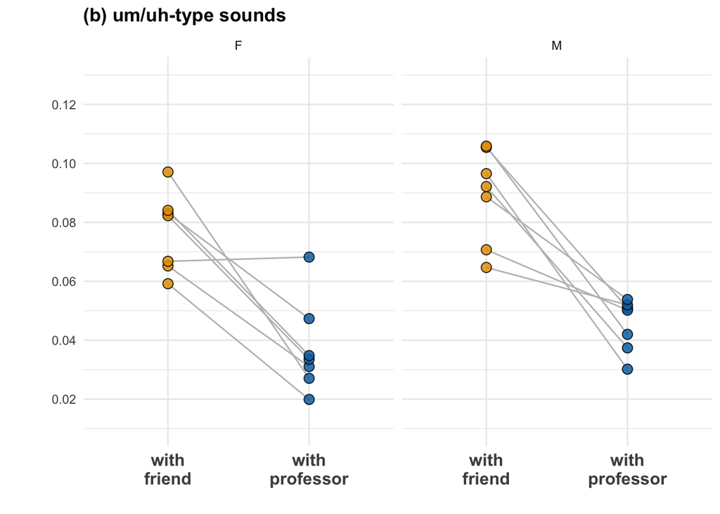

```r
fillers_p + facet_wrap(~Sex)
```

Picture looks not markedly difference for the two genders.

## Settings for Bayesian analysis (same across all)

Settings for parallel processing:

```r
options(mc.cores=parallel::detectCores())
```

Weakly informative priors:

```r
my_priors <- c(prior('normal(0, 2)', class = 'b'))
```

Control parameters for MCMC sampling:

```r
my_controls <- list(adapt_delta = 0.999,
                    max_treedepth = 13)
```

Iterations for all chains:

```r
my_iter <- 6000
my_warmup <- 4000
```

## Loop through all run Bayesian models

Create an empty data frame with the relevant stats:

```r
bayes_res <- data.frame(var = var_nodur)
bayes_res$Estimate <- NA
bayes_res$SE <- NA
bayes_res$Lower <- NA
bayes_res$Upper <- NA
bayes_res$PostAboveZero <- NA
bayes_res$PostBelowZero <- NA
bayes_res$p_AboveZero <- NA
bayes_res$p_BelowZero <- NA
```

Create the bit of the model formula that doesn’t change:

```r
formula_constant <- ' ~ Condition + offset(LogDur) + (1 + Condition|ID) + (1 + Condition|Task)'
```

The loop:

```r
for (i in seq_along(var_nodur)) {
  var <- var_nodur[i]
  this_formula <- as.formula(str_c(var, formula_constant))

  # Run the model:

  this_mdl <- brm(formula = this_formula,
                  family = 'negbinomial',
                  data = lex,
                  prior = my_priors,
                  control = my_controls,
                  seed = 42,
                  init = 0, chains = 4,
                  iter = my_iter, warmup = my_warmup)

  # Save the model:

  save(this_mdl, file = str_c('../models/', var_nodur[i], '.mdl'),
       compress = 'xz', compression_level = 9)

  # Save the estimates and upper and lower bound:

  x <- fixef(this_mdl)[2, ]

  # Extract fixed effects coefficients:

  bayes_res[i, ]$Estimate <- x['Estimate']
  bayes_res[i, ]$SE <- x['Est.Error']
  bayes_res[i, ]$Lower <- x['Q2.5']
  bayes_res[i, ]$Upper <- x['Q97.5']

  # Extract posteriors:

  posts <- posterior_samples(this_mdl)
  bayes_res[i, ]$PostAboveZero <- sum(posts$b_Condition > 0)
  bayes_res[i, ]$PostBelowZero <- sum(posts$b_Condition < 0)
  bayes_res[i, ]$p_AboveZero <- sum(posts$b_Condition > 0) / nrow(posts)
  bayes_res[i, ]$p_BelowZero <- sum(posts$b_Condition < 0) / nrow(posts)
}
```

Write Bayes summary table to file:

```r
write_csv(bayes_res, '../summary_tables/bayes_results.csv')
```

## Different analysis approach for datives and comitatives

The above analysis includes datives and comitatives for comparison’s sake (treating them like any other count variable). However, the analysis that will ultimately be of a different nature since the eykey/hanthey are mutually exclusive, and we want to model the relative choice of the two. The same goes for kwa vs. hago/rang.

```r
# Get relevant variables:

lex_dative <- select(lex,
                     ID, Condition, Task, LogDur,
                     dative_eykey, dative_hanthey)

# Make into long format with the datives:

lex_dative <- pivot_longer(lex_dative,
                           cols = dative_eykey:dative_hanthey,
                           values_to = 'n',
                           names_to = 'DativeType') %>%
  mutate(DativeType = str_replace(DativeType, 'dative_', ''))

# Check:

lex_dative
```

```
## # A tibble: 280 x 6
##       ID Condition Task     LogDur DativeType     n
##    <dbl> <chr>     <chr>     <dbl> <chr>      <dbl>
##  1     1 friend    Movie      5.83 eykey          0
##  2     1 friend    Movie      5.83 hanthey        2
##  3     1 friend    Tweety     5.02 eykey          0
##  4     1 friend    Tweety     5.02 hanthey        0
##  5     1 friend    RolePlay   5.04 eykey          0
##  6     1 friend    RolePlay   5.04 hanthey        1
##  7     1 friend    Map1       5.81 eykey          0
##  8     1 friend    Map1       5.81 hanthey        2
##  9     1 friend    Map2       5.31 eykey          0
## 10     1 friend    Map2       5.31 hanthey        0
## # … with 270 more rows
```

The numbers are very low anyway:

```r
lex_dative$n
```

```
##   [1] 0 2 0 0 0 1 0 2 0 0 0 0 0 1 0 2 1 2 0 0 0 5 0 4 0 3 0 0 0 0 0 5 0 0 0 1 0
##  [38] 0 0 0 0 7 0 3 0 1 0 2 0 0 0 1 0 1 0 0 0 0 0 0 0 0 0 1 0 0 0 0 0 0 0 3 0 0
##  [75] 0 0 0 0 0 0 0 0 0 2 0 2 0 0 0 0 0 2 0 3 0 0 0 0 0 0 0 2 0 0 0 0 0 0 0 0 0
## [112] 2 0 2 0 0 0 2 0 0 0 0 0 0 0 0 0 0 0 0 0 5 0 2 0 1 0 0 0 0 0 0 0 0 2 0 0 0
## [149] 0 0 0 1 0 1 4 0 0 0 0 0 0 0 0 2 3 0 0 0 0 0 0 1 0 0 1 1 0 0 0 0 0 1 0 0 0
## [186] 0 0 0 0 0 0 2 2 0 0 0 0 0 0 0 0 1 0 1 0 0 0 0 0 0 0 5 0 0 2 1 0 0 0 0 0 0
## [223] 1 0 0 1 0 0 0 0 0 0 0 4 0 0 0 0 0 0 0 3 0 2 0 0 0 0 0 0 0 4 0 0 0 0 0 0 0
## [260] 0 0 3 0 0 2 0 0 0 0 0 0 2 0 3 0 0 0 0 0 0
```

We will model the interaction between condition and dativetype.

```r
dative_mdl <- brm(n ~ Condition * DativeType +
                    (1 + Condition * DativeType|ID) +
                    (1 + Condition * DativeType|Task),
                  family = 'negbinomial',
                  data = lex_dative,
                  prior = my_priors,
                  control = my_controls,
                  seed = 42,
                  init = 0, chains = 4,
                  iter = my_iter, warmup = my_warmup)

# Save the model:

save(dative_mdl, file = '../models/datives_mdl.RData',
     compress = 'xz', compression_level = 9)
```

Summarize this model:

```r
summary(dative_mdl)
```

```
##  Family: negbinomial
##   Links: mu = log; shape = identity
## Formula: n ~ Condition * DativeType + (1 + Condition * DativeType | ID) + (1 + Condition * DativeType | Task)
##    Data: lex_dative (Number of observations: 280)
## Samples: 4 chains, each with iter = 6000; warmup = 4000; thin = 1;
##          total post-warmup samples = 8000
##
## Group-Level Effects:
## ~ID (Number of levels: 14)
##                                                              Estimate Est.Error
## sd(Intercept)                                                    0.37      0.28
## sd(Conditionprofessor)                                           0.39      0.31
## sd(DativeTypehanthey)                                            0.41      0.30
## sd(Conditionprofessor:DativeTypehanthey)                         0.56      0.41
## cor(Intercept,Conditionprofessor)                               -0.15      0.45
## cor(Intercept,DativeTypehanthey)                                -0.16      0.46
## cor(Conditionprofessor,DativeTypehanthey)                       -0.11      0.45
## cor(Intercept,Conditionprofessor:DativeTypehanthey)             -0.18      0.45
## cor(Conditionprofessor,Conditionprofessor:DativeTypehanthey)    -0.13      0.45
## cor(DativeTypehanthey,Conditionprofessor:DativeTypehanthey)     -0.16      0.44
##                                                              l-95% CI u-95% CI
## sd(Intercept)                                                    0.01     1.04
## sd(Conditionprofessor)                                           0.02     1.14
## sd(DativeTypehanthey)                                            0.02     1.12
## sd(Conditionprofessor:DativeTypehanthey)                         0.03     1.50
## cor(Intercept,Conditionprofessor)                               -0.88     0.75
## cor(Intercept,DativeTypehanthey)                                -0.89     0.75
## cor(Conditionprofessor,DativeTypehanthey)                       -0.86     0.77
## cor(Intercept,Conditionprofessor:DativeTypehanthey)             -0.89     0.74
## cor(Conditionprofessor,Conditionprofessor:DativeTypehanthey)    -0.87     0.77
## cor(DativeTypehanthey,Conditionprofessor:DativeTypehanthey)     -0.87     0.73
##                                                              Rhat Bulk_ESS
## sd(Intercept)                                                1.00     3405
## sd(Conditionprofessor)                                       1.00     3832
## sd(DativeTypehanthey)                                        1.00     3006
## sd(Conditionprofessor:DativeTypehanthey)                     1.00     3034
## cor(Intercept,Conditionprofessor)                            1.00     8227
## cor(Intercept,DativeTypehanthey)                             1.00     6636
## cor(Conditionprofessor,DativeTypehanthey)                    1.00     5962
## cor(Intercept,Conditionprofessor:DativeTypehanthey)          1.00     6630
```

[output cut: 64 more lines]

```
## DativeTypehanthey                        2.69      1.21     0.01     4.78 1.00
## Conditionprofessor:DativeTypehanthey    -1.89      1.29    -4.24     0.92 1.00
##                                      Bulk_ESS Tail_ESS
## Intercept                                7098     5671
## Conditionprofessor                       5597     5856
## DativeTypehanthey                        4694     4875
## Conditionprofessor:DativeTypehanthey     5596     5303
##
## Family Specific Parameters:
##       Estimate Est.Error l-95% CI u-95% CI Rhat Bulk_ESS Tail_ESS
## shape     3.14      9.00     0.68    12.86 1.00     4214     2994
##
## Samples were drawn using sampling(NUTS). For each parameter, Bulk_ESS
## and Tail_ESS are effective sample size measures, and Rhat is the potential
## scale reduction factor on split chains (at convergence, Rhat = 1).
```

Do the same for comitatives:

```r
# Get relevant variables:

lex_com <- select(lex,
                  ID, Condition, Task, LogDur,
                  kwa, hago_lang)

# Make into long format with the datives:

lex_com <- pivot_longer(lex_com,
                        cols = kwa:hago_lang,
                        values_to = 'n',
                        names_to = 'ComitativeType')

# Check:

lex_com
```

```
## # A tibble: 280 x 6
##       ID Condition Task     LogDur ComitativeType     n
##    <dbl> <chr>     <chr>     <dbl> <chr>          <dbl>
##  1     1 friend    Movie      5.83 kwa                0
##  2     1 friend    Movie      5.83 hago_lang          0
##  3     1 friend    Tweety     5.02 kwa                0
##  4     1 friend    Tweety     5.02 hago_lang          0
##  5     1 friend    RolePlay   5.04 kwa                0
##  6     1 friend    RolePlay   5.04 hago_lang          0
##  7     1 friend    Map1       5.81 kwa                0
##  8     1 friend    Map1       5.81 hago_lang          0
##  9     1 friend    Map2       5.31 kwa                0
## 10     1 friend    Map2       5.31 hago_lang          0
## # … with 270 more rows
```

The numbers are very low anyway:

```r
lex_com$n
```

```
##   [1] 0 0 0 0 0 0 0 0 0 0 0 0 0 0 0 0 2 0 0 2 0 0 0 0 0 0 0 2 1 1 0 0 1 0 0 0 0
##  [38] 0 0 0 0 0 0 0 0 0 0 0 0 2 0 0 0 0 0 0 0 0 0 1 0 0 0 0 0 0 0 0 0 0 0 0 0 0
##  [75] 0 0 0 3 0 0 0 0 0 0 0 0 0 1 0 0 0 0 0 0 0 0 1 0 1 3 0 0 0 0 0 0 1 1 2 5 0
## [112] 0 0 0 0 0 0 3 0 2 0 0 0 0 0 0 0 1 0 1 0 0 0 0 0 0 0 2 2 1 0 0 0 0 0 0 0 0
## [149] 0 0 0 0 0 0 0 0 0 0 0 0 0 0 0 0 1 0 0 0 0 0 0 0 0 0 1 0 0 0 0 0 0 0 0 0 0
## [186] 0 0 3 0 0 0 0 0 0 0 0 0 0 0 0 0 0 0 0 0 0 0 0 0 1 0 0 1 0 0 0 1 0 0 0 0 0
## [223] 0 0 0 0 0 4 0 0 1 0 0 0 0 0 0 0 0 0 0 0 0 0 0 0 0 2 0 0 0 0 0 0 0 0 0 0 0
## [260] 0 0 0 0 0 0 0 1 1 0 0 1 0 0 0 0 0 1 2 0 0
```

Build the model:

```r
com_mdl <- brm(n ~ Condition * ComitativeType +
                    (1 + Condition * ComitativeType|ID) +
                    (1 + Condition * ComitativeType|Task),
                  family = 'negbinomial',
                  data = lex_com,
                  prior = my_priors,
                  control = my_controls,
                  seed = 42,
                  init = 0, chains = 4,
                  iter = my_iter, warmup = my_warmup)

# Save the model:

save(com_mdl, file = '../models/com_mdl.RData',
     compress = 'xz', compression_level = 9)
```

Summarize the model:

```r
summary(com_mdl)
```

```
##  Family: negbinomial
##   Links: mu = log; shape = identity
## Formula: n ~ Condition * ComitativeType + (1 + Condition * ComitativeType | ID) + (1 + Condition * ComitativeType | Task)
##    Data: lex_com (Number of observations: 280)
## Samples: 4 chains, each with iter = 6000; warmup = 4000; thin = 1;
##          total post-warmup samples = 8000
##
## Group-Level Effects:
## ~ID (Number of levels: 14)
##                                                              Estimate Est.Error
## sd(Intercept)                                                    0.50      0.34
## sd(Conditionprofessor)                                           0.68      0.51
## sd(ComitativeTypekwa)                                            0.76      0.59
## sd(Conditionprofessor:ComitativeTypekwa)                         1.01      0.81
## cor(Intercept,Conditionprofessor)                               -0.10      0.44
## cor(Intercept,ComitativeTypekwa)                                 0.02      0.44
## cor(Conditionprofessor,ComitativeTypekwa)                       -0.11      0.45
## cor(Intercept,Conditionprofessor:ComitativeTypekwa)             -0.03      0.44
## cor(Conditionprofessor,Conditionprofessor:ComitativeTypekwa)    -0.16      0.45
## cor(ComitativeTypekwa,Conditionprofessor:ComitativeTypekwa)     -0.03      0.44
##                                                              l-95% CI u-95% CI
## sd(Intercept)                                                    0.02     1.29
## sd(Conditionprofessor)                                           0.02     1.91
## sd(ComitativeTypekwa)                                            0.03     2.23
## sd(Conditionprofessor:ComitativeTypekwa)                         0.04     3.02
## cor(Intercept,Conditionprofessor)                               -0.85     0.77
## cor(Intercept,ComitativeTypekwa)                                -0.80     0.82
## cor(Conditionprofessor,ComitativeTypekwa)                       -0.87     0.77
## cor(Intercept,Conditionprofessor:ComitativeTypekwa)             -0.82     0.78
## cor(Conditionprofessor,Conditionprofessor:ComitativeTypekwa)    -0.87     0.74
## cor(ComitativeTypekwa,Conditionprofessor:ComitativeTypekwa)     -0.82     0.80
##                                                              Rhat Bulk_ESS
## sd(Intercept)                                                1.00     2284
## sd(Conditionprofessor)                                       1.00     2820
## sd(ComitativeTypekwa)                                        1.00     3674
## sd(Conditionprofessor:ComitativeTypekwa)                     1.00     3473
## cor(Intercept,Conditionprofessor)                            1.00     7949
## cor(Intercept,ComitativeTypekwa)                             1.00     7488
## cor(Conditionprofessor,ComitativeTypekwa)                    1.00     5963
## cor(Intercept,Conditionprofessor:ComitativeTypekwa)          1.00     8920
```

[output cut: 64 more lines]

```
## ComitativeTypekwa                       -0.51      1.01    -2.20     1.78 1.00
## Conditionprofessor:ComitativeTypekwa     0.73      1.20    -1.62     3.14 1.00
##                                      Bulk_ESS Tail_ESS
## Intercept                                3738     4923
## Conditionprofessor                       5877     5798
## ComitativeTypekwa                        4743     4782
## Conditionprofessor:ComitativeTypekwa     7131     6661
##
## Family Specific Parameters:
##       Estimate Est.Error l-95% CI u-95% CI Rhat Bulk_ESS Tail_ESS
## shape    10.38     27.36     0.54    81.23 1.00     3847     6330
##
## Samples were drawn using sampling(NUTS). For each parameter, Bulk_ESS
## and Tail_ESS are effective sample size measures, and Rhat is the potential
## scale reduction factor on split chains (at convergence, Rhat = 1).
```

There’s lots of zeros. What about a subset analysis with just those that have SOME dative or SOME comitative. Then we can use logistic regression.

Get the total number of datives and the total number of comitatives:

```r
lex <- mutate(lex,
              dative_n = dative_eykey + dative_hanthey,
              com_n = hago_lang + kwa)
```

There’s a number of 0’s, which doesn’t work for binomial models. So we’ll do a subjects-only analysis in this case:

```r
lex_sub <- lex %>% group_by(ID, Condition, Task) %>%
  summarize(dative_n = sum(dative_n),
            dative_eykey = sum(dative_eykey),
            com_n = sum(com_n),
            kwa = sum(kwa))
lex_sub
```

```
## # A tibble: 140 x 7
## # Groups:   ID, Condition [28]
##       ID Condition Task     dative_n dative_eykey com_n   kwa
##    <dbl> <chr>     <chr>       <dbl>        <dbl> <dbl> <dbl>
##  1     1 friend    Map1            2            0     0     0
##  2     1 friend    Map2            0            0     0     0
##  3     1 friend    Movie           2            0     0     0
##  4     1 friend    RolePlay        1            0     0     0
##  5     1 friend    Tweety          0            0     0     0
##  6     1 professor Map1            0            0     0     0
##  7     1 professor Map2            0            0     0     0
##  8     1 professor Movie           0            0     0     0
##  9     1 professor RolePlay        2            2     0     0
## 10     1 professor Tweety          0            0     0     0
## # … with 130 more rows
```

Get the subsets (separately):

```r
dative_no_zero <- filter(lex_sub,
                         dative_n > 0)
com_no_zero <- filter(lex_sub,
                      com_n > 0)

# Check how many that is:

nrow(dative_no_zero)
```

```
## [1] 55
```

```r
nrow(com_no_zero)
```

```
## [1] 31
```

What in terms of subjects?

```r
length(unique(dative_no_zero$ID))
```

```
## [1] 14
```

```r
length(unique(com_no_zero$ID))
```

```
## [1] 13
```

OK, so let’s do it. First, the datives:

```r
dative_binom_mdl <- brm(dative_eykey | trials(dative_n) ~ Condition +
                          (1 + Condition|ID) +
                          (1 + Condition|Task),
                        family = 'binomial',
                        data = dative_no_zero,
                        prior = my_priors,
                        control = my_controls,
                        seed = 42,
                        init = 0, chains = 4,
                        iter = my_iter, warmup = my_warmup)

# Save the model:

save(dative_binom_mdl, file = '../models/dative_binom_mdl.RData',
     compress = 'xz', compression_level = 9)
```

Then, the comitatives:

```r
com_binom_mdl <- brm(kwa | trials(com_n) ~ Condition +
                          (1 + Condition|ID) +
                          (1 + Condition|Task),
                        family = 'binomial',
                        data = com_no_zero,
                        prior = my_priors,
                        control = my_controls,
                        seed = 42,
                        init = 0, chains = 4,
                        iter = my_iter, warmup = my_warmup)

# Save the model:

save(com_binom_mdl, file = '../models/com_binom_mdl.RData',
     compress = 'xz', compression_level = 9)
```

Summarize both models:

```r
summary(dative_binom_mdl)
```

[output not shown]

```r
summary(com_binom_mdl)
```

```
##  Family: binomial
##   Links: mu = logit
## Formula: kwa | trials(com_n) ~ Condition + (1 + Condition | ID) + (1 + Condition | Task)
##    Data: com_no_zero (Number of observations: 31)
## Samples: 4 chains, each with iter = 6000; warmup = 4000; thin = 1;
##          total post-warmup samples = 8000
##
## Group-Level Effects:
## ~ID (Number of levels: 13)
##                                   Estimate Est.Error l-95% CI u-95% CI Rhat
## sd(Intercept)                         0.73      0.64     0.02     2.37 1.00
## sd(Conditionprofessor)                2.04      1.76     0.07     6.39 1.00
## cor(Intercept,Conditionprofessor)    -0.06      0.57    -0.95     0.94 1.00
##                                   Bulk_ESS Tail_ESS
## sd(Intercept)                         2894     3830
## sd(Conditionprofessor)                3613     3653
## cor(Intercept,Conditionprofessor)     5024     5574
##
## ~Task (Number of levels: 5)
##                                   Estimate Est.Error l-95% CI u-95% CI Rhat
## sd(Intercept)                         2.34      2.06     0.09     7.40 1.00
## sd(Conditionprofessor)                2.29      2.18     0.09     7.80 1.00
## cor(Intercept,Conditionprofessor)     0.18      0.56    -0.90     0.97 1.00
##                                   Bulk_ESS Tail_ESS
## sd(Intercept)                         3049     3587
## sd(Conditionprofessor)                5495     5204
## cor(Intercept,Conditionprofessor)     7023     5527
##
## Population-Level Effects:
##                    Estimate Est.Error l-95% CI u-95% CI Rhat Bulk_ESS Tail_ESS
## Intercept              0.11      1.56    -2.17     3.92 1.00     3635     4450
## Conditionprofessor     0.54      1.41    -2.19     3.41 1.00     6071     5574
##
## Samples were drawn using sampling(NUTS). For each parameter, Bulk_ESS
## and Tail_ESS are effective sample size measures, and Rhat is the potential
## scale reduction factor on split chains (at convergence, Rhat = 1).
```

This completes this analysis.